# BANTER for Beaked Whales: North Atlantic

Shannon Rankin

2023-01-26

## PAMpal Data Processing

Start by loading the required packages

```r
library (PAMpal)
library(banter)
library(rfPermute)
library(kableExtra)
library(readxl)
library(stringr)
library(dplyr)
library(here)
here()
```

```
## [1] "C:/Users/shannon.rankin/Documents/GitHub/BANTER_BeakedWhales"
```

1. **Set up our PPS** (PAMPal Settings Object) for the NAtlantic dataset

```r
pps <- PAMpalSettings(db='Database/',
                      binaries = 'Binaries/',
                      sr_hz='auto',
                      winLen_sec=.0025,
                      filterfrom_khz=10,
                      filterto_khz=NULL)
```

2. **Process data** and save to file to eliminate repeated processing.

```r
data <- processPgDetections(pps, mode='db', id='natlantic_bw')
saveRDS(data, 'natlantic_study.rds')
# Double check warning messages
print(getWarnings(data)$message)
```

3. **Assign species identity** according to original PAMguard labels, then relabel for consistency across projects.

   *Final species ID for beaked whale detections was provided by A. DeAngelis as an excel spreadsheet. The following code chunk pulls out the required information (event, species) in the format required for PAMpal.*

```r
HB1603 <- read_excel("HB1603_BWs.xlsx", sheet = "Alldata")#read in data
HB1603 <- filter(HB1603, !eventType == "BRAN")
#create formatted event/species dataframe
speciesID <- HB1603[c("PGId", "Final Species Classification", "Database")] %>%
  mutate("event" = paste(Database, PGId, sep=".OE")) %>%
  rename("species" = "Final Species Classification") %>%
  mutate("species" = str_replace_all(species, "'", ""),
         "species" = str_replace(species, "Gervais/Trues", "BW")) %>%
  select(all_of(c("event", "species")))

#Assign species ID to data
data <- setSpecies(data, method='manual', value = speciesID)
#Note: 156 detections are not given species IDs and will be filtered out at a later step.
```

4. **Filter out unwanted data**: Subset and rename species for BANTER model

```r
goodSpecies<- c(c("Trues", "Cuviers", "Sowerbys", "Gervais"))
data <- filter(data, species %in% goodSpecies)
```

5. **Calculate Inter-Click Interval** (ICI).

```r
data <- calculateICI(data, time='peakTime')
```

6. **Export data for BANTER** (and drop species codes that will not be used for training). We will create two datasets: one with ICI and one without ICI, and save these for import into BANTER.

```r
banter_data <- export_banter(data, dropSpecies = 'unid',
                         dropVars = c('All_ici'), training=TRUE)
saveRDS(banter_data, file='natlantic_banter_data.rds')

banter_data_ici <- export_banter(data, dropSpecies = 'unid', training=TRUE)
saveRDS(banter_data_ici, file='natlantic_banter_data_ici.rds')

#save update of Acoustic Study
saveRDS(data, 'natlantic_study.rds')
```

## Build a BANTER Classification Model

### *Model without ICI*

1. Load data, initialize a BANTER model, and create an initial BANTER detector model (stage 1).

```r
banter_model <- initBanterModel(banter_data$events)
banter_model <- addBanterDetector(banter_model, banter_data$detectors, ntree=5e3, sampsize=3, importance = TRUE)
```

Check for stability (are more trees needed?) before moving on

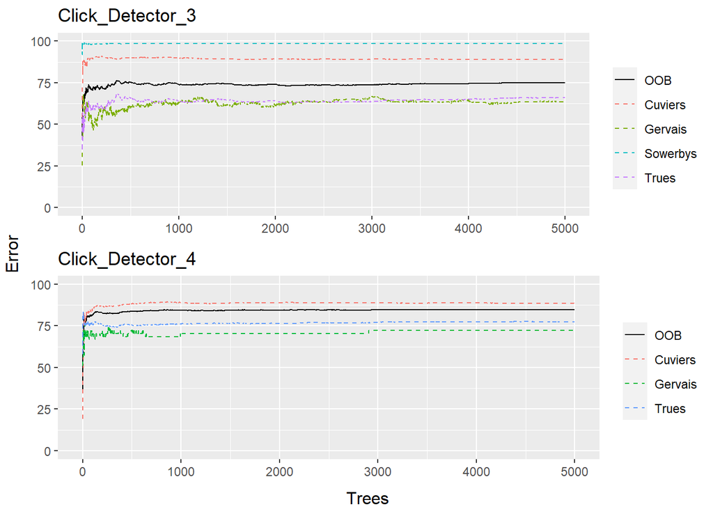

```r
plotDetectorTrace(banter_model, detector = paste0('Click_Detector_', 3:4))
```

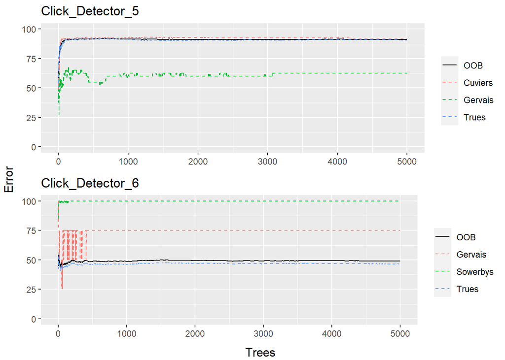

```r
plotDetectorTrace(banter_model, detector = paste0('Click_Detector_', 5:6))
```

```r
summary(banter_model)
```

```
## Model run times:
##                  start                 stop                  run.time
## Click_Detector_3 "2023-02-10 09:15:28" "2023-02-10 09:15:43" "14.44 secs"
## Click_Detector_4 "2023-02-10 09:15:43" "2023-02-10 09:15:49" "6.25 secs"
## Click_Detector_5 "2023-02-10 09:15:49" "2023-02-10 09:15:51" "2.48 secs"
## Click_Detector_6 "2023-02-10 09:15:51" "2023-02-10 09:15:52" "1.13 secs"
## event            "2023-02-10 09:16:25" "2023-02-10 09:16:26" "0.78 secs"
##
## Number of events and model classification rate:
##    species num.events Click_Detector_3 Click_Detector_4 Click_Detector_5
## 1  Cuviers        120            89.11            88.64            92.21
## 2  Gervais          4            63.59            72.22            62.50
## 3 Sowerbys          6            98.58               NA               NA
## 4    Trues         76            66.05            77.45            90.72
## 5  Overall        206            75.08            84.64            91.16
##   Click_Detector_6 event
## 1               NA   100
## 2            75.00    NA
## 3           100.00   100
## 4            46.57   100
## 5            48.99   100
```

```
##
## << Summary for "event" model >>
```

```
##
## Number of trees: 5000
##
## Sample sizes:
##  Cuviers Sowerbys    Trues
##        4        4        4
##
## Distribution of percent correctly classified overall in last 2500 (50%) trees:
##    Min. 1st Qu.  Median    Mean 3rd Qu.    Max.
##     100     100     100     100     100     100
##
## Sample inbag proportion distribution:
##          Min. 1st Qu. Median Mean 3rd Qu. Max.
## expected  3.3     4.3    5.3 25.1    36.0 66.7
## observed  2.8     3.3    3.6  5.9     5.2 67.1
##
## Confusion matrix:
##          Cuviers Sowerbys Trues pct.correct LCI_0.95 UCI_0.95
## Cuviers      120        0     0         100 96.97270      100
## Sowerbys       0        6     0         100 54.07419      100
## Trues          0        0    76         100 95.26212      100
## Overall       NA       NA    NA         100 98.19040      100
```

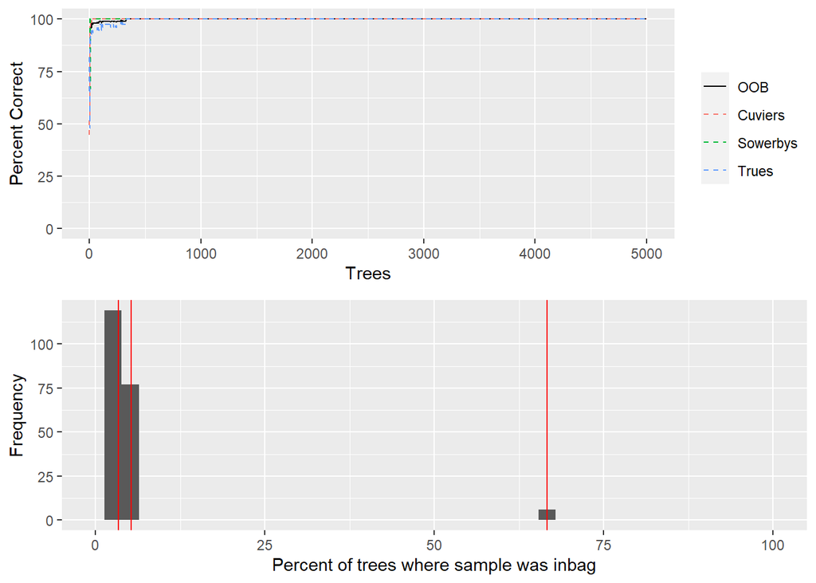

2. Run BANTER Event Model (stage 2)

```r
banter_model <- runBanterModel(banter_model, ntree=5e3, sampsize=4)
summary(banter_model)
```

```
## Model run times:
##                  start                 stop                  run.time
## Click_Detector_3 "2023-02-10 09:15:28" "2023-02-10 09:15:43" "14.44 secs"
## Click_Detector_4 "2023-02-10 09:15:43" "2023-02-10 09:15:49" "6.25 secs"
## Click_Detector_5 "2023-02-10 09:15:49" "2023-02-10 09:15:51" "2.48 secs"
## Click_Detector_6 "2023-02-10 09:15:51" "2023-02-10 09:15:52" "1.13 secs"
## event            "2023-02-10 09:20:13" "2023-02-10 09:20:13" "0.79 secs"
##
## Number of events and model classification rate:
##    species num.events Click_Detector_3 Click_Detector_4 Click_Detector_5
## 1  Cuviers        120            89.11            88.64            92.21
## 2  Gervais          4            63.59            72.22            62.50
## 3 Sowerbys          6            98.58               NA               NA
## 4    Trues         76            66.05            77.45            90.72
## 5  Overall        206            75.08            84.64            91.16
##   Click_Detector_6 event
## 1               NA   100
## 2            75.00    NA
## 3           100.00   100
## 4            46.57   100
## 5            48.99   100
```

```
##
## << Summary for "event" model >>
```

```
##
## Number of trees: 5000
##
## Sample sizes:
##  Cuviers Sowerbys    Trues
##        4        4        4
##
## Distribution of percent correctly classified overall in last 2500 (50%) trees:
##    Min. 1st Qu.  Median    Mean 3rd Qu.    Max.
##     100     100     100     100     100     100
##
## Sample inbag proportion distribution:
##          Min. 1st Qu. Median Mean 3rd Qu. Max.
## expected  3.3     4.3    5.3 25.1    36.0 66.7
## observed  2.8     3.3    3.7  5.9     5.2 67.4
##
## Confusion matrix:
##          Cuviers Sowerbys Trues pct.correct LCI_0.95 UCI_0.95
## Cuviers      120        0     0         100 96.97270      100
## Sowerbys       0        6     0         100 54.07419      100
## Trues          0        0    76         100 95.26212      100
## Overall       NA       NA    NA         100 98.19040      100
```

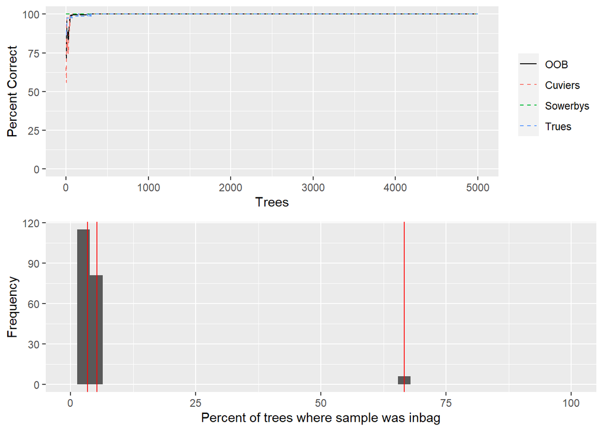

Check for stability (are more trees needed?). If acceptable, save model with tree/sampsize info in the filename.

```r
saveRDS(banter_model, 'natlantic_banter_model_t5e3s3_t5e3s4.rds')
```

### *ICI Model*

1. Load data, initialize a BANTER model, and create an initial BANTER detector model (stage 1).

```r
banter_model_ici <- initBanterModel(banter_data_ici$events)
banter_model_ici <- addBanterDetector(banter_model_ici, banter_data_ici$detectors, ntree=10e3, sampsize=2, importance = TRUE)
```

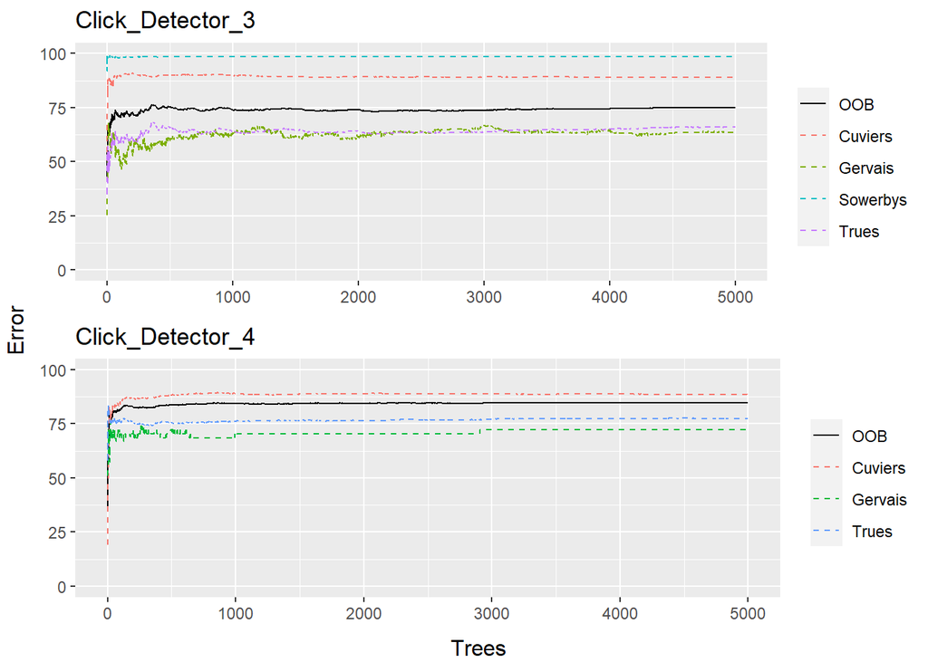

```r
plotDetectorTrace(banter_model, detector = paste0('Click_Detector_', 3:4))
```

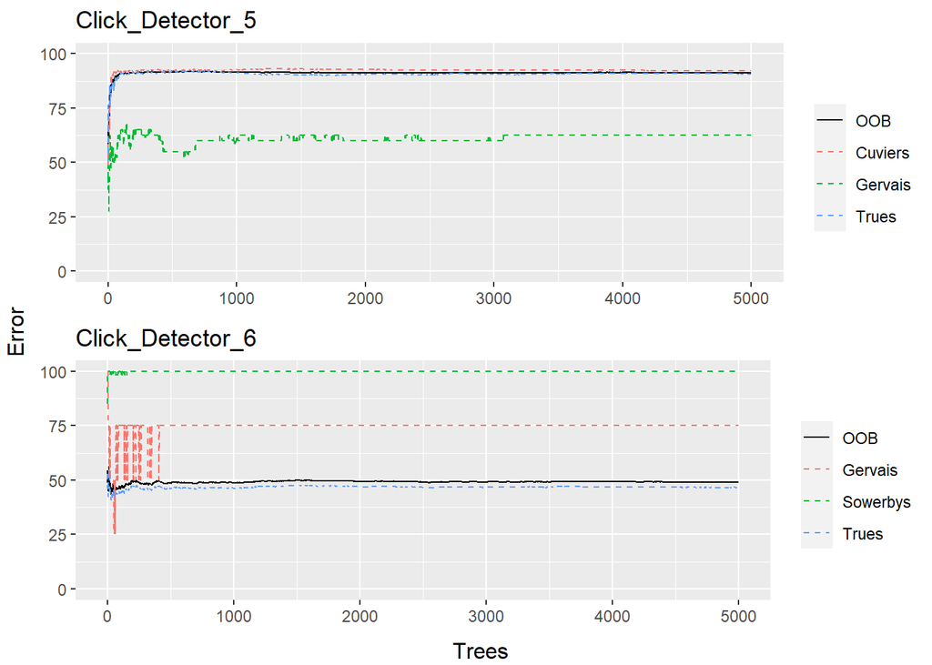

```r
plotDetectorTrace(banter_model, detector = paste0('Click_Detector_', 5:6))
```

```r
summary(banter_model_ici)
```

```
## Model run times:
##                  start                 stop                  run.time
## Click_Detector_3 "2023-02-10 09:16:47" "2023-02-10 09:17:12" "25.38 secs"
## Click_Detector_4 "2023-02-10 09:17:12" "2023-02-10 09:17:23" "11.12 secs"
## Click_Detector_5 "2023-02-10 09:17:23" "2023-02-10 09:17:28" "4.39 secs"
## Click_Detector_6 "2023-02-10 09:17:28" "2023-02-10 09:17:30" "1.69 secs"
## event            "2023-02-10 09:17:54" "2023-02-10 09:17:55" "1.24 secs"
##
## Number of events and model classification rate:
##    species num.events Click_Detector_3 Click_Detector_4 Click_Detector_5
## 1  Cuviers        120            89.13            89.34            92.78
## 2  Gervais          4            63.59            70.37            35.00
## 3 Sowerbys          6            98.58               NA               NA
## 4    Trues         76            61.68            76.08            91.86
## 5  Overall        206            72.45            84.61            91.65
##   Click_Detector_6  event
## 1               NA  99.17
## 2            75.00     NA
## 3           100.00 100.00
## 4            44.28 100.00
## 5            46.81  99.50
```

```
##
## << Summary for "event" model >>
```

```
##
## Number of trees: 10000
##
## Sample sizes:
##  Cuviers Sowerbys    Trues
##        4        4        4
##
## Distribution of percent correctly classified overall in last 5000 (50%) trees:
##    Min. 1st Qu.  Median    Mean 3rd Qu.    Max.
##   99.50   99.50   99.50   99.63   99.50  100.00
##
## Sample inbag proportion distribution:
##          Min. 1st Qu. Median Mean 3rd Qu. Max.
## expected  3.3     4.3    5.3 25.1    36.0 66.7
## observed  2.8     3.3    3.5  5.9     5.2 66.9
##
## Confusion matrix:
##          Cuviers Sowerbys Trues pct.correct LCI_0.95  UCI_0.95
## Cuviers      119        0     1    99.16667 95.44445  99.97890
## Sowerbys       0        6     0   100.00000 54.07419 100.00000
## Trues          0        0    76   100.00000 95.26212 100.00000
## Overall       NA       NA    NA    99.50495 97.27277  99.98747
```

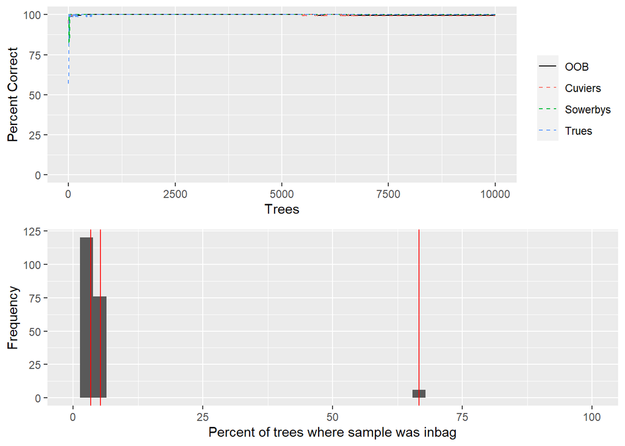

2. Run BANTER Event Model (stage 2)

```r
banter_model_ici <- runBanterModel(banter_model_ici, ntree=10e3, sampsize=4)
summary(banter_model_ici)
```

```
## Model run times:
##                  start                 stop                  run.time
## Click_Detector_3 "2023-02-10 09:16:47" "2023-02-10 09:17:12" "25.38 secs"
## Click_Detector_4 "2023-02-10 09:17:12" "2023-02-10 09:17:23" "11.12 secs"
## Click_Detector_5 "2023-02-10 09:17:23" "2023-02-10 09:17:28" "4.39 secs"
## Click_Detector_6 "2023-02-10 09:17:28" "2023-02-10 09:17:30" "1.69 secs"
## event            "2023-02-10 09:20:17" "2023-02-10 09:20:19" "1.27 secs"
##
## Number of events and model classification rate:
##    species num.events Click_Detector_3 Click_Detector_4 Click_Detector_5
## 1  Cuviers        120            89.13            89.34            92.78
## 2  Gervais          4            63.59            70.37            35.00
## 3 Sowerbys          6            98.58               NA               NA
## 4    Trues         76            61.68            76.08            91.86
## 5  Overall        206            72.45            84.61            91.65
##   Click_Detector_6 event
## 1               NA   100
## 2            75.00    NA
## 3           100.00   100
## 4            44.28   100
## 5            46.81   100
```

```
##
## << Summary for "event" model >>
```

```
##
## Number of trees: 10000
##
## Sample sizes:
##  Cuviers Sowerbys    Trues
##        4        4        4
##
## Distribution of percent correctly classified overall in last 5000 (50%) trees:
##    Min. 1st Qu.  Median    Mean 3rd Qu.    Max.
##   99.01   99.01   99.50   99.46  100.00  100.00
##
## Sample inbag proportion distribution:
##          Min. 1st Qu. Median Mean 3rd Qu. Max.
## expected  3.3     4.3    5.3 25.1    36.0 66.7
## observed  2.9     3.3    3.5  5.9     5.2 67.6
##
## Confusion matrix:
##          Cuviers Sowerbys Trues pct.correct LCI_0.95 UCI_0.95
## Cuviers      120        0     0         100 96.97270      100
## Sowerbys       0        6     0         100 54.07419      100
## Trues          0        0    76         100 95.26212      100
## Overall       NA       NA    NA         100 98.19040      100
```

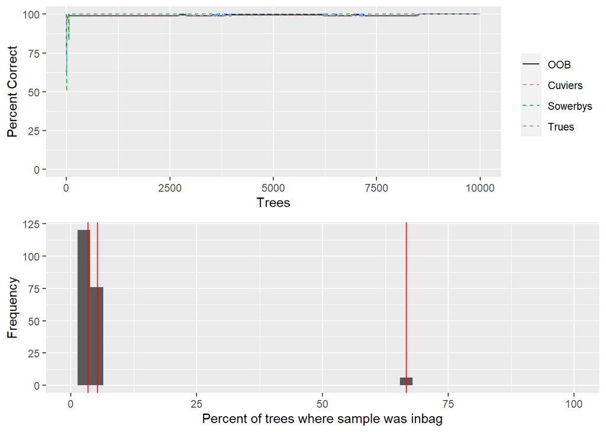

Check for stability (are more trees needed?). If acceptable, save model with tree/sampsize info in the filename.

```r
saveRDS(banter_model_ici, 'natlantic_banter_model_ici_t10e3s2_t10e3s4.rds')
```

## BANTER Analytics

There are a number of visualizations/data products that allow us to visualize our BANTER classifier; most use the rfPermute package (see [BANTER Guidelines](https://taikisan21.github.io/PAMpal/banterGuide.html) for more information)

First, identify the model you would like to examine (comment out the model you do not want to examine).

```r
model <- banter_model
modelname <- "banter_model"

model_ici <- banter_model_ici
modelname_ici <- "banter_model_ici"
```

Extract the Random Forest model object from our BANTER model for analysis.

```r
banter_model_RF <- getBanterModel(model)
banter_model_ici_RF <- getBanterModel(model_ici)
```

Confusion Matrix (simple model)

```r
natlantic_confuseMatrix <- rfPermute::confusionMatrix(banter_model_RF)
natlantic_confuseMatrix <- kable(natlantic_confuseMatrix, align = "c", digits = c(0,0,0,0,2,2,2))%>%
  kable_classic()%>%
  column_spec(4, border_right = TRUE)%>%
  row_spec(0, bold = TRUE)%>%
  row_spec(3,hline_after = TRUE)%>%
  row_spec(4, bold = TRUE)%>%
  save_kable(paste(modelname, "natlantic_confuseMatrix.png", sep="_"), zoom = 2)
```

```
## save_kable will have the best result with magick installed.
```

```r
natlantic_ici_confuseMatrix <- rfPermute::confusionMatrix(banter_model_ici_RF)
natlantic_ici_confuseMatrix <- kable(natlantic_ici_confuseMatrix, align = "c", digits = c(0,0,0,0,2,2,2))%>%
  kable_classic()%>%
  column_spec(4, border_right = TRUE)%>%
  row_spec(0, bold = TRUE)%>%
  row_spec(3,hline_after = TRUE)%>%
  row_spec(4, bold = TRUE)%>%
  save_kable(paste(modelname_ici, "natlantic_ici_confuseMatrix.png", sep="_"), zoom = 2)
```

```
## save_kable will have the best result with magick installed.
```

[figure not shown]

Proximity Plot

```r
png(paste(modelname, "natlantic_proximity.png", sep="_"), width = 20, height = 20, units = 'cm', res = 300)
hawaii_proximityPlot <- plotProximity(banter_model_RF)
dev.off()
```

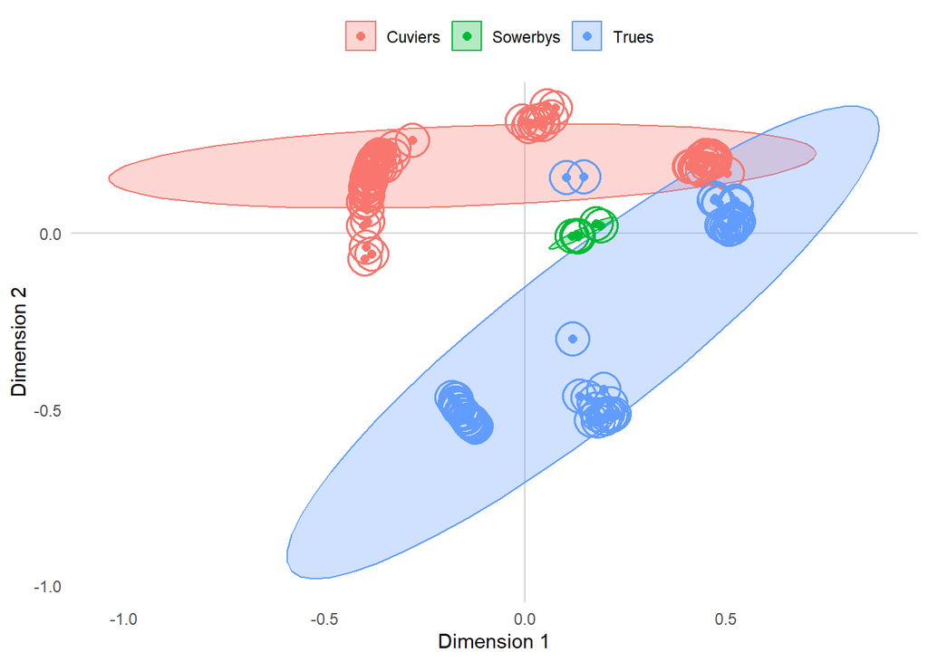

```r
hawaii_proximityPlot <- plotProximity(banter_model_RF)
```

```r
png(paste(modelname_ici, "natlantic_proximity.png", sep="_"), width = 20, height = 20, units = 'cm', res = 300)
ici_hawaii_proximityPlot <- plotProximity(banter_model_ici_RF)
dev.off()
```

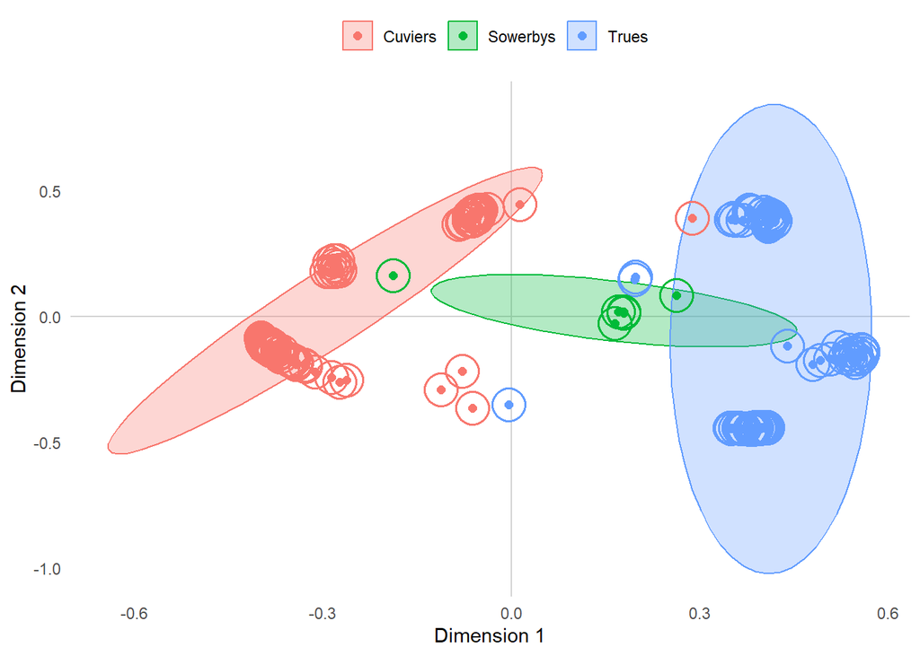

```r
ici_hawaii_proximityPlot <- plotProximity(banter_model_ici_RF)
```

Importance Heatmap

```r
png(paste(modelname, "natlantic_importance.png", sep="_"), width = 30, height = 25, units = 'cm', res = 300)
plotImportance(banter_model_RF, plot.type="heatmap")
dev.off()
```

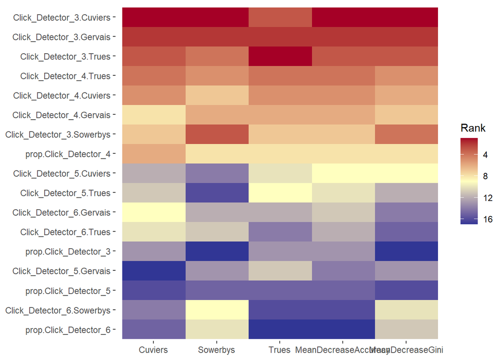

```r
hawaii_importance <- plotImportance(banter_model_RF, plot.type="heatmap")
```

```r
png(paste(modelname_ici, "natlantic_importance.png", sep="_"), width = 30, height = 25, units = 'cm', res = 300)
plotImportance(banter_model_ici_RF, plot.type="heatmap")
dev.off()
```

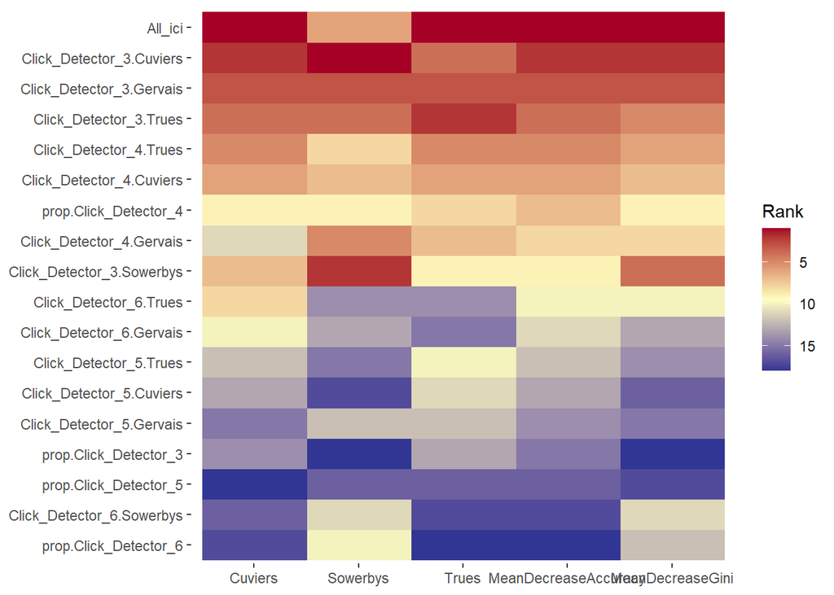

```r
ici_hawaii_importance <- plotImportance(banter_model_ici_RF, plot.type="heatmap")
```

PlotVotes

```r
png(paste(modelname, "natlantic_votes.png", sep="_"), width = 20, height = 20, units = 'cm',  res = 300)
plotVotes(banter_model_RF)
dev.off()
```

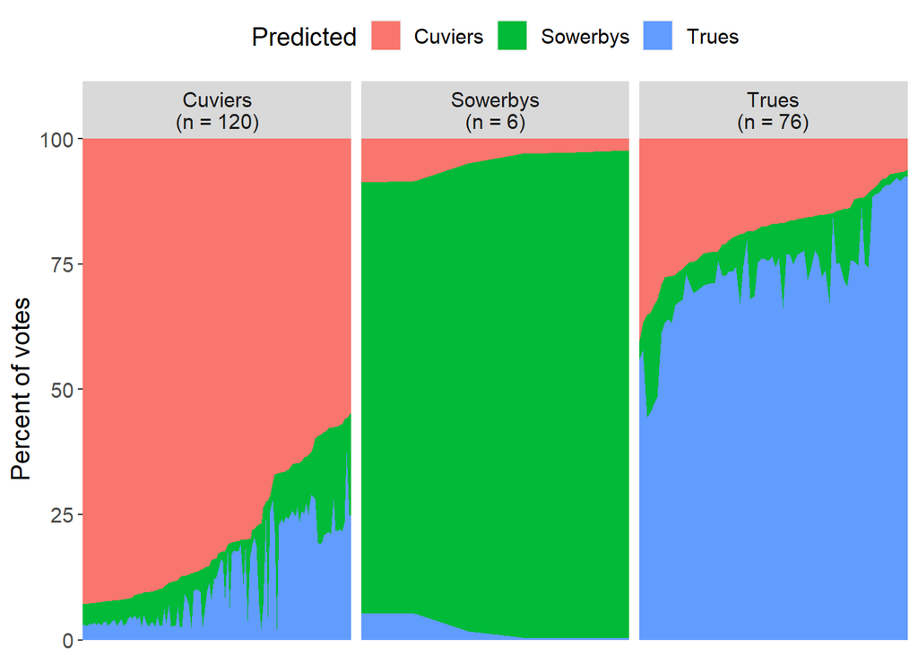

```r
hawaii_votes <- plotVotes(banter_model_RF)
```

```r
png(paste(modelname_ici, "natlantic_votes.png", sep="_"), width = 20, height = 20, units = 'cm',  res = 300)
plotVotes(banter_model_ici_RF)
dev.off()
```

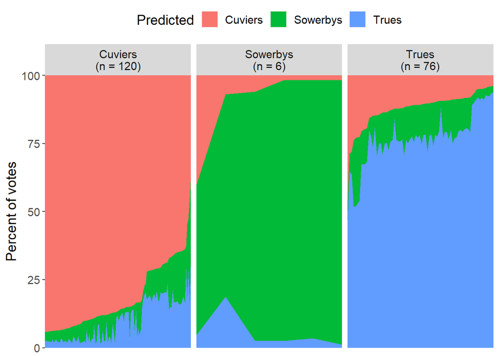

```r
ici_hawaii_votes <- plotVotes(banter_model_ici_RF)
```

Class Priors (Expected Error Rate)

```r
hawaii_priors <- classPriors(banter_model_RF, NULL)
```

Plot Confusion Matrix Heat Map

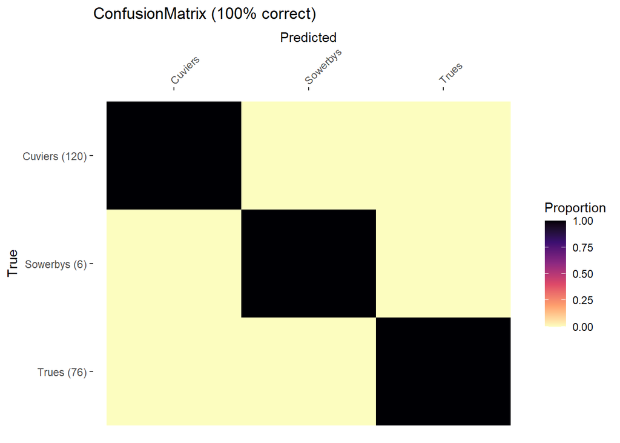

```r
plotConfMat(banter_model_RF, title="ConfusionMatrix", plot=TRUE)
```

Plot Error Trace for Banter Model

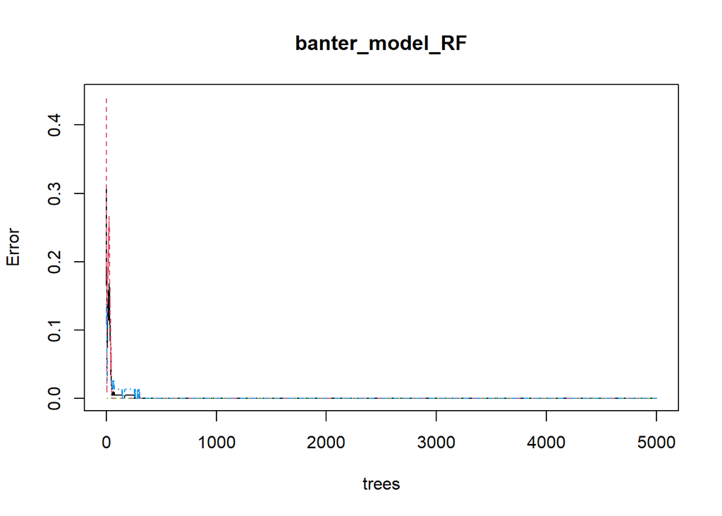

```r
plot(banter_model_RF)
```

Plot Predicted Probabilities

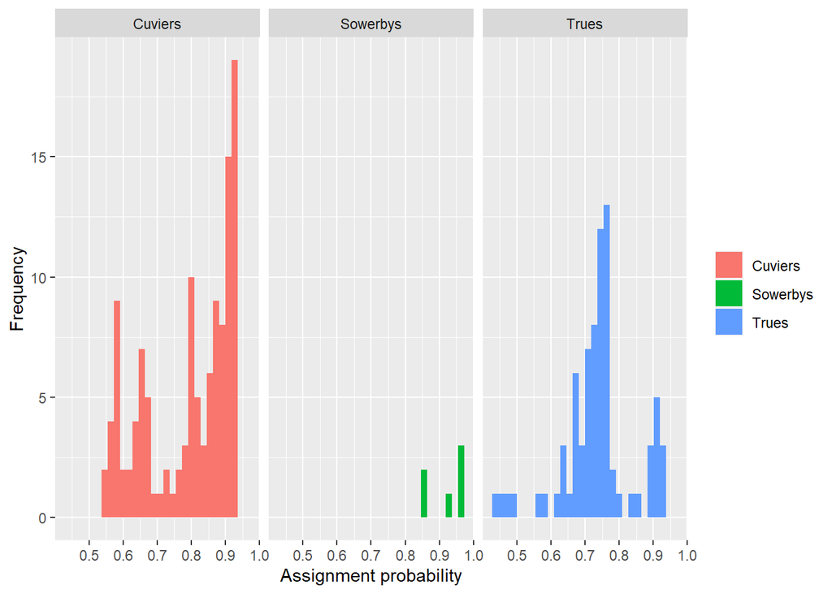

```r
plotPredictedProbs(banter_model_RF, bins=30, plot=TRUE)
```